# 싸진 판단은 어디서 정직한가

# 4 경계에서 나온 것: 신뢰도가 중간에서 뒤집힌다

여기서부터가 이 글의 본론이다.

Jev를 파는 쪽의 핵심 주장은 속도가 아니라 **캘리브레이션**이다. 대형 언어모델은 사람이 좋아할 답을 쓰도록 학습됐지만, Jev는 다른 학습법으로 **“0.9라고 답한 것이 실제로 90% 맞도록”** 맞춰 놨다고 한다.

이것이 사실이라면 정확도 62%는 문제가 되지 않는다. 확신할 때만 쓰고 나머지는 넘기면 되기 때문이다. 그래서 따로 쟀다.

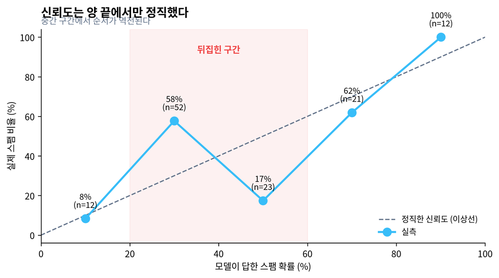

그림 4: 캘리브레이션 곡선. 가로축은 모델이 답한 스팸 확률, 세로축은 그 구간의 실제 스팸 비율. 점선(대각선) 위에 놓이면 신뢰도가 정직한 것이다. 막대 위 숫자는 구간별 표본 수. 출처: 본 실험 120건.

양 끝은 놀랍도록 정확하다. **0.2 이하라고 답한 것들은 실제로 8%만 스팸이었고, 0.8 이상이라고 답한 것들은 100% 스팸이었다.** 광고한 그대로다.

그런데 중간이 무너져 있다.

| 모델이 답한 확률 | 실제 스팸 비율 | 판정 |
| --- | --- | --- |
| 0.0 ~ 0.2 | 8% | 정직 |
| **0.2 ~ 0.4** | **58%** | **역전** |
| **0.4 ~ 0.6** | **17%** | **역전** |
| 0.6 ~ 0.8 | 62% | 정직 |
| 0.8 ~ 1.0 | 100% | 정직 |

0.3이라고 답한 것이 0.5라고 답한 것보다 **세 배 이상 더 스팸이다.** 순서가 뒤집혀 있다. 이 구간에서 신뢰도는 정보가 아니라 잡음이다.

그리고 이 구간이 **전체의 62%**를 차지한다.

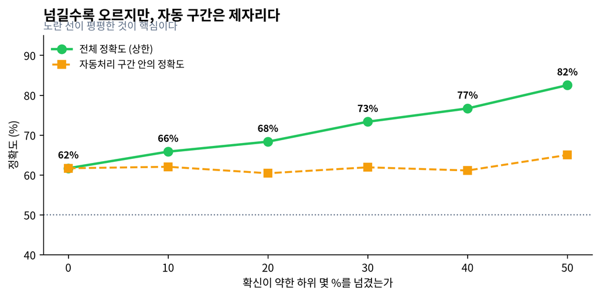

그림 5: 확신이 약한 것부터 사람 또는 대형모델에 넘겼을 때의 전체 정확도. 넘긴 건은 모두 맞춘다고 가정한 상한선이므로 실제로는 이보다 낮다. 출처: 본 실험 120건.

절반을 넘겨야 82%에 닿는다. 더 중요한 것은 **노란 선이 거의 평평하다**는 점이다. 확신이 약한 것들을 걷어내도 남은 것들의 정확도가 오르지 않는다. 걷어낸 기준이 **틀릴 것들을 실제로 골라내지 못했다**는 뜻이다.

# 5 세 분야가 각각 말하는 것

## 5.1 인지과학: 시스템 1은 자기 불확실성을 모른다

카너먼의 이중과정 이론에서 시스템 1의 특징은 빠름이 아니라 **자동성**이다. 그리고 그 대가로, 시스템 1은 자신이 언제 틀리는지를 스스로 신호하지 못한다. 판단을 멈추고 시스템 2를 부르는 결정은 시스템 1 안에서 나오지 않는다.

측정된 곡선은 이 구조를 거의 그대로 재현한다. 다만 **부분적으로** 그렇다. 양 끝에서는 정직하고 중간에서만 무너진다. 즉 이 모델은 “확신할 때는 자기를 알고, 애매할 때는 자기를 모른다.”

이것은 시스템 1의 완전한 재현도, 실패도 아니다. **자기 인식이 균일하지 않은 시스템 1**이다.

## 5.2 측정심리학: 평균 캘리브레이션은 구간 캘리브레이션을 보장하지 않는다

예보의 신뢰도를 평가할 때 쓰는 기본 도구가 캘리브레이션 곡선이다. 그리고 이 분야가 오래전부터 아는 사실이 있다. **총합으로 잘 맞춰진 모델도 구간별로는 얼마든지 비단조일 수 있다.**

전체 평균만 보면 이 모델은 “대체로 캘리브레이션됐다”고 보고될 수 있다. 실제로 양 끝의 표본 24건은 거의 완벽하다. 그러나 구간을 쪼개면 중간 62%가 뒤집혀 있다.

**평균을 보고 임계값 0.5를 설계하면 반드시 실패한다.** 오늘 측정한 62%가 정확히 그 실패다.

## 5.3 경제학: 제번스 역설에는 전제가 있다

제번스의 관찰은 효율이 오르면 총소비가 는다는 것이었다. 석탄 기관의 효율이 좋아지자 석탄을 더 캤다.

그러나 석탄 기관에는 이 글이 발견한 문제가 없었다. 효율이 오른 기관은 **모든 작업 구간에서 고르게** 일했다. 싼 판단은 다르다. 싸졌지만 **고르지 않다.**

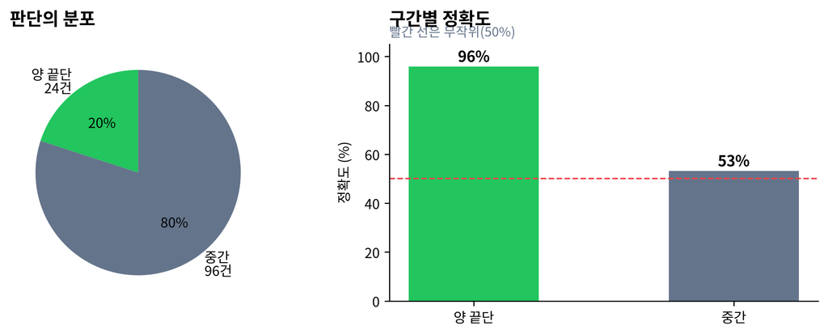

그림 6: 싸진 판단 중 실제로 신뢰할 수 있는 몫. 양 끝단(확률 0.2 이하 또는 0.8 이상)만 자동 처리하고 나머지를 넘기는 설계에서, 자동 처리 가능한 비율과 그 구간의 정확도. 출처: 본 실험 120건.

양 끝단은 정확하지만 **전체의 일부**다. 중간은 다수지만 쓸 수 없다.

그러므로 제번스 역설의 전제를 다시 써야 한다.

# 6 경계에서만 나오는 명제

> **싼 판단의 확산은 정확도가 아니라 “버리는 설계”에 의해 결정된다.**

> 판단 단가가 250배 떨어져도, 그 판단이 신뢰 구간 전체에서 고르게 정직하지 않다면 총소비는 늘지 않는다. 늘리려면 **모델이 애매하다고 말한 구간을 통째로 포기하는 구조**를 먼저 만들어야 한다. 제번스 역설은 효율의 함수가 아니라 **선별 비용의 함수**다.

세 분야 중 하나만으로는 이 명제에 닿지 않는다.

- 인지과학만으로는 **“시스템 1은 원래 그렇다”**에서 멈춘다. 얼마나, 어느 구간에서 그런지 말하지 못한다.
- 측정심리학만으로는 **비단조 캘리브레이션이라는 기술적 결함**을 보고하고 끝난다. 그것이 왜 경제적으로 중요한지 말하지 않는다.
- 경제학만으로는 **가격이 떨어졌으니 소비가 는다**고 예측한다. 실제로는 늘지 않을 수 있다는 조건을 보지 못한다.

세 개를 겹쳐야 비로소 이렇게 말할 수 있다. **효율은 충분조건이 아니다. 자기 불확실성을 정직하게 신고하는 구간의 넓이가 곧 확산의 상한이다.**

# 7 설계로 옮기면

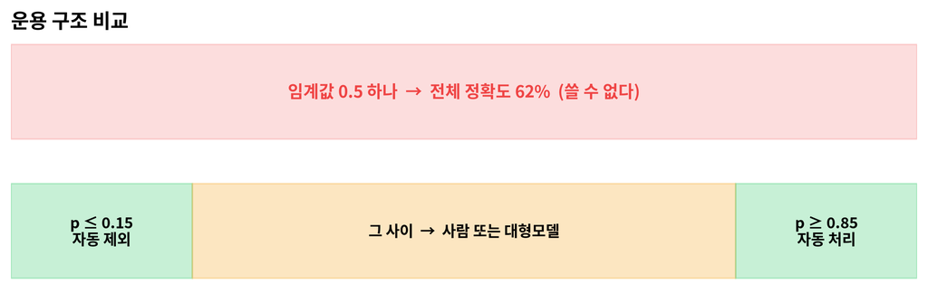

그림 7: 측정 결과가 지시하는 운용 구조. 임계값을 0.5 하나로 두는 설계와, 양 끝단만 신뢰하는 설계의 차이. 출처: 본 실험 해석.

측정이 지시하는 규칙은 단순하다.

1. **임계값을 0.5로 두지 않는다.** 그 자리가 가장 부정확하다.
2. **양 끝단만 자동화한다.** 0.85 이상과 0.15 이하.
3. **중간은 통째로 사람 또는 대형모델에 넘긴다.** 선별하려 애쓰지 않는다 — 선별 기준 자체가 그 구간에서 무너져 있다.
4. **입력과 확률을 전부 기록한다.** 이 모델은 이유를 남기지 않는다. 기록이 없으면 왜 걸러졌는지 영원히 알 수 없다.

# 8 왜 실데이터여야 했는가

이 실험에서 가장 중요한 방법론적 선택은 모델이 아니라 **표본**이었다.

앞선 실험에서 같은 계열의 공개 모델을 합성 예문으로 평가한 적이 있다. 그때 결론은 “양호함”이었다. 직접 작성한 정상 메일 예문은 짧고 깨끗해서 우연히 통과했기 때문이다.

실제 수신함을 열자 결론이 뒤집혔다. 진짜 메일에는 헤더 잔해와 광고 문구와 깨진 HTML이 섞여 있고, 무엇보다 **“내가 이것을 구독한 적이 있는가”라는 정보가 메일 안에 없다.**

오탐 목록을 보면 분명해진다. 추석 멤버스데이 안내, 온톨로지 강의 광고, 채용 알림, 의족 기술 뉴스레터 — **객관적으로는 전부 마케팅이 맞다.** 모델이 틀린 것이 아니다. 정답이 본문 바깥에 있었을 뿐이다.

이것이 싼 판단이 잘하는 일과 못하는 일을 가르는 선이다. **답이 텍스트 표면에 있으면 된다. 맥락이나 개인 이력이 답을 정하면 안 된다.**

**경고반대 해석과 한계**

**1. 과제 하나의 결과다.** 스팸 판정은 개인 이력이 답을 정하는 과제다. 이 과제에서의 비단조 캘리브레이션이 분류·라우팅·점수 매기기 전반으로 일반화된다는 근거는 없다. 표면 단서가 충분한 과제에서는 중간 구간도 정직할 수 있다.

**2. 표본이 작다.** 120건이고, 구간별로는 12~52건이다. 0.8 이상 구간의 “100%”는 12건 위에 서 있다. 구간 경계를 조금만 옮겨도 그림이 달라질 수 있다. 재현이 필요하다.

**3. 정답 라벨 자체가 완벽하지 않다.** 메일 서비스의 자동 분류를 정답으로 삼았다. 그 분류도 틀린다. 특히 정상함에 들어온 광고 메일은 서비스가 통과시킨 것일 뿐 “원하는 메일”이라는 뜻이 아니다. **모델과 정답이 같은 종류의 실수를 하고 있을 가능성**을 배제하지 못했다.

**4. 제번스 해석은 과잉일 수 있다.** 역설의 원래 맥락은 산업 전체의 연료 수요였다. 개별 모델의 캘리브레이션 곡선을 거기에 대응시키는 것은 유비이지 증명이 아니다. 판단 단가 하락이 실제로 총 판단량을 늘리는지는 이 실험으로 확인되지 않는다. 그것은 앞으로 몇 년의 채택 데이터가 답할 문제다.

**5. 반대 방향의 해석.** 중간 구간이 뒤집힌 것을 결함이 아니라 **정보**로 볼 수도 있다. 모델이 0.3~0.5를 답한다는 것 자체가 “이 입력에는 판단 근거가 없다”는 신호일 수 있고, 그렇다면 그 구간의 정확도가 낮은 것은 모델이 정직한 결과다. 이 해석이 맞다면 고쳐야 할 것은 모델이 아니라 **질문**이다.

# 9 남는 질문

Muse는 판단을 사람 대신 **실행**하는 쪽으로 갔고, Jev는 판단만 **값싸게 공급**하는 쪽으로 갔다. 두 방향은 결국 만난다. 실행하려면 판단이 필요하고, 싼 판단은 실행될 곳을 찾는다.

그때 남는 질문은 정확도가 아니다.

**애매하다고 말할 줄 아는 구간이 얼마나 넓은가.** 이 글의 측정으로는 20%였다. 그 숫자가 늘어나는 속도가, 앞으로 사람이 판단에서 물러나도 되는 속도다.

# 10 참고 문헌

- Kahneman, D. *Thinking, Fast and Slow*. Farrar, Straus and Giroux, 2011. — 이중과정 이론, 시스템 1의 자동성과 자기 불확실성 인식의 부재.
- Jevons, W. S. *The Coal Question*. Macmillan, 1865. — 효율 향상이 총소비를 증가시키는 역설.
- Murphy, A. H. “A New Vector Partition of the Probability Score.” *Journal of Applied Meteorology*, 1973. — 신뢰도 점수의 캘리브레이션·분해능 분해.
- DeGroot, M. H. & Fienberg, S. E. “The Comparison and Evaluation of Forecasters.” *The Statistician*, 1983. — 예보자 캘리브레이션 평가 틀.
- TypeSafe AI, Jev 모델 공개 문서 및 OpenRouter 제공 명세(2026-09). — 가격·응답 규격·학습 방식 설명.
- Meta, “Introducing Muse: personal AI agent” (2026-09-08) 및 후속 공개 발표(2026-09-23). — 가격 등급, 연동 서비스, 웨어러블 계획.
- 본 실험 원자료: `output/data/sp25_jev_bench.json` (실제 수신 메일 120건, 제목·발신자 등 식별 정보 제거 후 라벨·확률만 공개).